# hw3_Question2

Sruti Devendran, sd3159

3/1/2018

## Analysis of the aquifer pollutants

### Introduction

We are looking at data on aquifer pollutants. This data set is collected from 42 small urban drainage basins located in several cities around the United States and sourced from the book “Statistical Methods in Water Resources” by D.R. Helsel and R.M. Hirsch (this texbook further cites Mustard et al., 1987).

We are most interested in understanding how the total nitrogen load in these basins can be predicted based on the other 8 variables (listed below).

The packages used in this exercise are: dplyr, ggplot2, mvinfluence, MASS

## Analysis

```r
if(!require(pacman)) install.packages('pacman')
pacman::p_load(dplyr, readr)
library(MASS)
```

```r
app15 <- read_csv('appc15.csv') %>%
  setNames(tolower(names(.))) # variable names are lower case
glimpse(app15)
```

```
Observations: 42
Variables: 9
$ logda    <dbl> -0.34672, -2.32279, -3.05761, -1.36258, -2.14558, -3....
$ logimp   <dbl> 3.64806, 4.16044, 4.21509, 3.31419, 3.65066, 3.36730,...
$ mjtemp   <dbl> 15.3, 15.3, 15.3, 15.3, 15.3, 24.9, 24.9, 20.4, 11.4,...
$ msrain   <dbl> 20.24, 20.24, 20.24, 20.24, 20.24, 24.66, 24.66, 23.3...
$ pres     <int> 48, 0, 67, 55, 48, 100, 84, 81, 0, 30, 33, 0, 100, 0,...
$ pnon     <int> 28, 0, 0, 34, 0, 0, 0, 6, 0, 0, 37, 2, 0, 60, 58, 81,...
$ pcomm    <int> 5, 0, 33, 0, 0, 0, 16, 13, 100, 70, 30, 98, 0, 40, 36...
$ pind     <int> 19, 100, 0, 10, 52, 0, 0, 0, 0, 0, 0, 0, 0, 0, 0, 0, ...
$ nitrogen <dbl> 13.104032, 2.185009, 3.270000, 5.819998, 3.257989, 5....
```

The dataset has 42 observations, and 9 variables. To check if there is any relationship between the explanatory variables I visualized them using the pairs plot.

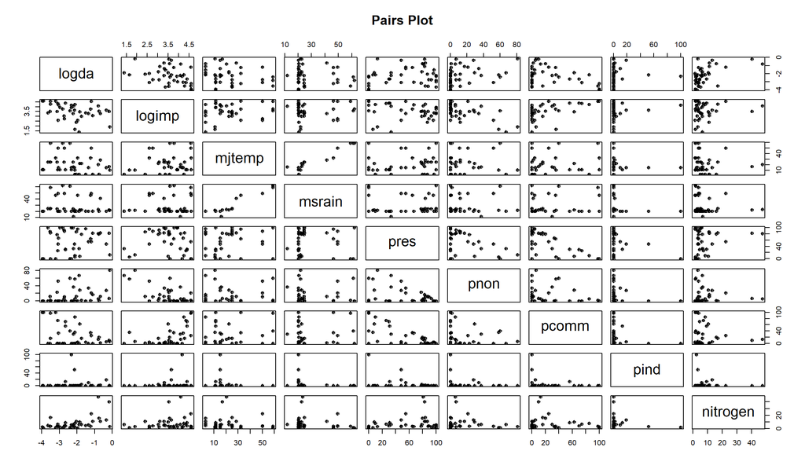

```r
pairs(app15, pch=10, cex =0.9, main = "Pairs Plot")
```

```r
lm1 <- lm(nitrogen ~ logda+ logimp + mjtemp + msrain + pres+ pnon+ pcomm + pind, data= app15)
summary(lm1)
```

```
Call:
lm(formula = nitrogen ~ logda + logimp + mjtemp + msrain + pres +
    pnon + pcomm + pind, data = app15)

Residuals:
   Min     1Q Median     3Q    Max
-8.962 -4.562 -0.011  1.483 23.892

Coefficients:
            Estimate Std. Error t value Pr(>|t|)
(Intercept) 238.2133   293.5228   0.812   0.4229
logda         7.0311     1.4410   4.879 2.63e-05 ***
logimp        3.1820     2.7316   1.165   0.2524
mjtemp        0.3868     0.2274   1.701   0.0984 .
msrain       -0.4864     0.2556  -1.903   0.0658 .
pres         -2.1819     2.9253  -0.746   0.4610
pnon         -2.2714     2.9405  -0.772   0.4453
pcomm        -2.1838     2.9245  -0.747   0.4605
pind         -2.3239     2.9360  -0.792   0.4343
---
Signif. codes:  0 '***' 0.001 '**' 0.01 '*' 0.05 '.' 0.1 ' ' 1

Residual standard error: 7.264 on 33 degrees of freedom
Multiple R-squared:  0.5173,    Adjusted R-squared:  0.4003
F-statistic: 4.421 on 8 and 33 DF,  p-value: 0.001034
```

It is not quite obvious, of how the relationship is between the nitrogen and other explanatory variables. I took the log of nitrogen variable, so that the presence of a negative intercept wont influence the value of nitrogen. I fitted a linear model with all the variables in the dataset.

```r
lm2 <- lm(log10(nitrogen) ~ logda+ logimp + mjtemp + msrain + pres+ pnon+ pcomm + pind, data= app15)
summary(lm2)
```

```
Call:
lm(formula = log10(nitrogen) ~ logda + logimp + mjtemp + msrain +
    pres + pnon + pcomm + pind, data = app15)

Residuals:
    Min      1Q  Median      3Q     Max
-0.4010 -0.1682 -0.0497  0.1719  0.5365

Coefficients:
             Estimate Std. Error t value Pr(>|t|)
(Intercept) -0.007921  10.784420  -0.001   0.9994
logda        0.258037   0.052943   4.874 2.67e-05 ***
logimp       0.149808   0.100362   1.493   0.1450
mjtemp       0.013447   0.008355   1.609   0.1170
msrain      -0.021542   0.009391  -2.294   0.0283 *
pres         0.011787   0.107480   0.110   0.9133
pnon         0.009647   0.108037   0.089   0.9294
pcomm        0.010663   0.107450   0.099   0.9216
pind         0.005115   0.107873   0.047   0.9625
---
Signif. codes:  0 '***' 0.001 '**' 0.01 '*' 0.05 '.' 0.1 ' ' 1

Residual standard error: 0.2669 on 33 degrees of freedom
Multiple R-squared:  0.5845,    Adjusted R-squared:  0.4838
F-statistic: 5.803 on 8 and 33 DF,  p-value: 0.0001209
```

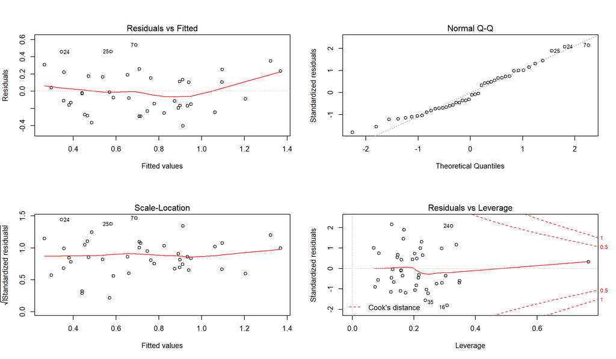

```r
par(mfrow=c(2,2))
plot(lm2)
```

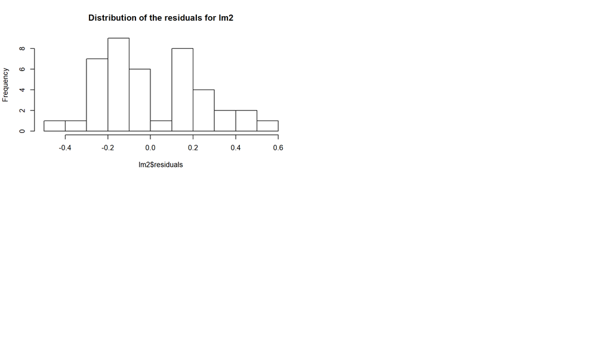

```r
hist(lm2$residuals, main="Distribution of the residuals for lm2")
```

```r
lm3 <- step(lm2, direction="both")
```

```
Start:  AIC=-103.09
log10(nitrogen) ~ logda + logimp + mjtemp + msrain + pres + pnon +
    pcomm + pind

         Df Sum of Sq    RSS      AIC
- pind    1   0.00016 2.3505 -105.087
- pnon    1   0.00057 2.3509 -105.080
- pcomm   1   0.00070 2.3511 -105.078
- pres    1   0.00086 2.3512 -105.075
<none>                2.3504 -103.090
- logimp  1   0.15869 2.5091 -102.346
- mjtemp  1   0.18449 2.5349 -101.916
- msrain  1   0.37474 2.7251  -98.877
- logda   1   1.69190 4.0423  -82.316

Step:  AIC=-105.09
log10(nitrogen) ~ logda + logimp + mjtemp + msrain + pres + pnon +
    pcomm

         Df Sum of Sq    RSS      AIC
- pnon    1   0.08879 2.4393 -105.530
<none>                2.3505 -105.087
- logimp  1   0.15916 2.5097 -104.335
- mjtemp  1   0.18483 2.5354 -103.908
+ pind    1   0.00016 2.3504 -103.090
- pcomm   1   0.28195 2.6325 -102.329
- msrain  1   0.37717 2.7277 -100.837
- pres    1   0.48449 2.8350  -99.216
- logda   1   1.78904 4.1396  -83.317

Step:  AIC=-105.53
log10(nitrogen) ~ logda + logimp + mjtemp + msrain + pres + pcomm

         Df Sum of Sq    RSS      AIC
- logimp  1   0.07207 2.5114 -106.307
<none>                2.4393 -105.530
+ pnon    1   0.08879 2.3505 -105.087
+ pind    1   0.08838 2.3509 -105.080
- pcomm   1   0.22305 2.6624 -103.855
- mjtemp  1   0.32326 2.7626 -102.303
- pres    1   0.44855 2.8879 -100.440
- msrain  1   0.51644 2.9558  -99.464
- logda   1   2.19863 4.6379  -80.543

Step:  AIC=-106.31
log10(nitrogen) ~ logda + mjtemp + msrain + pres + pcomm

         Df Sum of Sq    RSS      AIC
<none>                2.5114 -106.307
+ logimp  1   0.07207 2.4393 -105.530
+ pnon    1   0.00170 2.5097 -104.335
+ pind    1   0.00164 2.5097 -104.334
- mjtemp  1   0.53559 3.0470 -100.188
- pcomm   1   0.71197 3.2234  -97.824
- pres    1   0.72895 3.2403  -97.604
- msrain  1   0.78429 3.2957  -96.892
- logda   1   2.26142 4.7728  -81.339
```

```r
summary(lm3)
```

```
Call:
lm(formula = log10(nitrogen) ~ logda + mjtemp + msrain + pres +
    pcomm, data = app15)

Residuals:
     Min       1Q   Median       3Q      Max
-0.46821 -0.18105 -0.02099  0.17390  0.60233

Coefficients:
             Estimate Std. Error t value Pr(>|t|)
(Intercept)  1.222871   0.184075   6.643 9.69e-08 ***
logda        0.278214   0.048865   5.694 1.78e-06 ***
mjtemp       0.019712   0.007114   2.771  0.00879 **
msrain      -0.027678   0.008255  -3.353  0.00189 **
pres         0.005546   0.001716   3.233  0.00263 **
pcomm        0.006561   0.002054   3.195  0.00291 **
---
Signif. codes:  0 '***' 0.001 '**' 0.01 '*' 0.05 '.' 0.1 ' ' 1

Residual standard error: 0.2641 on 36 degrees of freedom
Multiple R-squared:  0.556, Adjusted R-squared:  0.4944
F-statistic: 9.017 on 5 and 36 DF,  p-value: 1.259e-05
```

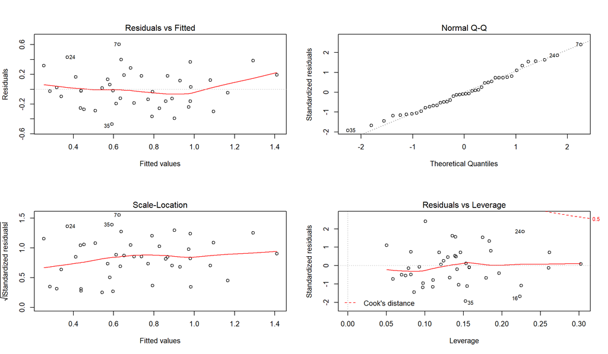

```r
par(mfrow=c(2,2))
plot(lm3)
```

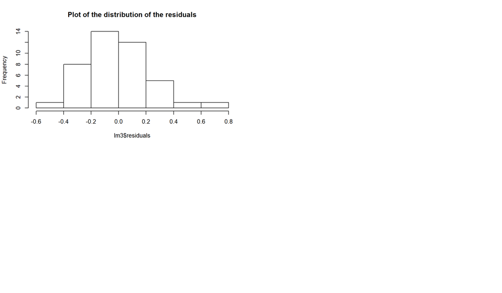

```r
hist(lm3$residuals, main = "Plot of the distribution of the residuals")
```

This gives a very good model.

Stepwise algorithm returns the following model as the best model:

The final model : log10(nitrogen) ~ logda + mjtemp + msrain + pres + pcomm, is chosen as the best model for this dataset. To check for points which influence the regression curve, and to find the points which have high standardized residual values and high leverage, I used an Influence Plot

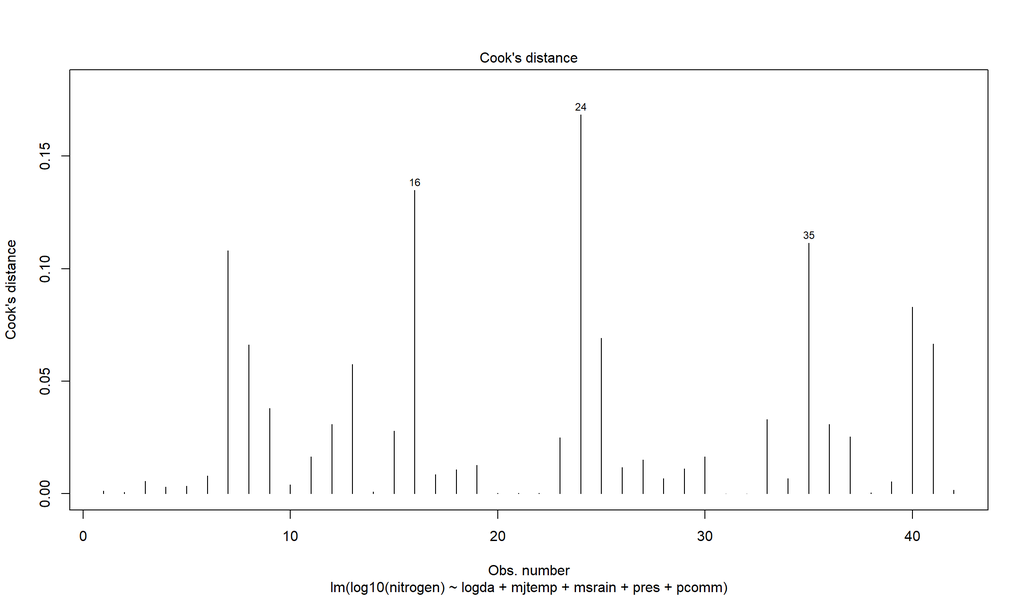

```r
# Cook's D plot
# identify D values > 4/(n-k-1)
library(mvinfluence)
cutoff <- 4/((nrow(app15)-length(lm3$coefficients)-2))
plot(lm3, which=4, cook.levels=cutoff)
```

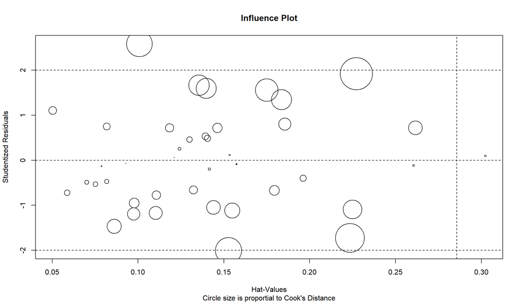

```r
# Influence Plot
influencePlot(lm3,  id.method="identify", main="Influence Plot", sub="Circle size is proportial to Cook's Distance" )
```

### Summary and Conclusions

Using a stepwise AIC algorithm, we can find the explanatory variables which are significant and can be included in the model. From the stepwise algorithm, the best model found was log10(nitrogen) ~ logda + mjtemp + msrain + pres + pcomm.